# Análise de GHI e Resultados dos Modelos para as Localidades de Fábricas de Veículos Elétricos

## Apresentação

Este notebook apresenta a aplicação do pipeline de previsão diária de Irradiância Solar Global Horizontal (GHI) em dez localidades associadas a fábricas de veículos elétricos.

O estudo foi desenvolvido em três etapas principais. Inicialmente, foram obtidos dados solares por meio da API da National Solar Radiation Database (NSRDB). Em seguida, realizou-se a caracterização das séries temporais de GHI. Por fim, o pipeline de pré-processamento e aprendizado de máquina foi aplicado individualmente a cada localidade, utilizando os modelos XGBoost e MLP.

O período histórico analisado compreende os anos de 2019 a 2024, correspondentes aos anos efetivamente disponibilizados pelo produto GOES Aggregated PSM v4 no momento da coleta.

## 1. Configuração do ambiente

```python
# Configura caminhos, bibliotecas e estilo compartilhado das visualizacoes.
import os
import sys
from pathlib import Path

PROJECT_ROOT = Path.cwd().resolve()
if PROJECT_ROOT.name == "cadernos_jupyter":
    PROJECT_ROOT = PROJECT_ROOT.parent
if str(PROJECT_ROOT) not in sys.path:
    sys.path.insert(0, str(PROJECT_ROOT))

os.environ.setdefault("MPLCONFIGDIR", str(PROJECT_ROOT / ".matplotlib-cache"))

import matplotlib.pyplot as plt
import numpy as np
import pandas as pd
from IPython.display import HTML, Markdown, display

from codigo_fonte.localidades_ev import (
    LOCALIDADES_EV,
    dataframe_localidades,
    distancia_haversine_km,
)
from treinar_todas_localidades import (
    MANIFESTO_DADOS,
    OUTPUT_DIR,
    calcular_sha256,
    nome_arquivo,
    validar_csv_nrel_localidade,
)

RESULTADOS_DIR = PROJECT_ROOT / "resultados" / "todas_localidades"
PREVISOES_DIR = RESULTADOS_DIR / "previsoes"

plt.style.use("seaborn-v0_8-whitegrid")
pd.set_option("display.max_colwidth", 100)

print("Ambiente configurado para a análise das dez localidades.")
```

```
Ambiente configurado para a análise das dez localidades.
```

## 2. Aquisição e organização dos dados

### 2.1 Fonte dos dados solares

Os dados solares foram obtidos por meio da API oficial da **National Solar Radiation Database (NSRDB)**, atualmente disponibilizada pela National Laboratory of the Rockies (NLR). Utilizou-se o produto **GOES Aggregated PSM v4**, com resolução temporal horária de 60 minutos.

Para cada localidade, os valores horários de GHI foram agrupados por dia por meio da média aritmética. Dessa forma, o valor diário representa a irradiância média horária observada ao longo das 24 horas, expressa em `W/m²`.

A mesma metodologia de coleta foi aplicada às dez localidades, preservando-se o período de 1º de janeiro de 2019 a 31 de dezembro de 2024.

### 2.2 Localidades selecionadas e fontes das coordenadas

A identificação de cada fábrica foi confirmada por meio de página institucional da respectiva empresa. As coordenadas geográficas foram associadas ao centro do elemento industrial correspondente no OpenStreetMap, consultado por meio do serviço Nominatim.

A tabela a seguir apresenta as localidades, os endereços utilizados e as respectivas fontes de referência.

```python
# Converte o cadastro auditavel em uma tabela com links clicaveis.
fontes = dataframe_localidades()[
    [
        "nome", "pais", "endereco", "lat", "lon",
        "fonte_localidade", "fonte_coordenadas",
    ]
].copy()

fontes["Fonte institucional"] = fontes["fonte_localidade"].map(
    lambda url: f'<a href="{url}" target="_blank">Página oficial</a>'
)
fontes["Fonte geográfica"] = fontes["fonte_coordenadas"].map(
    lambda url: f'<a href="{url}" target="_blank">OpenStreetMap</a>'
)

tabela_fontes = fontes.drop(columns=["fonte_localidade", "fonte_coordenadas"]).rename(
    columns={
        "nome": "Localidade",
        "pais": "País",
        "endereco": "Endereço",
        "lat": "Latitude",
        "lon": "Longitude",
    }
)

display(HTML(tabela_fontes.to_html(index=False, escape=False)))
```

| Localidade | País | Endereço | Latitude | Longitude | Fonte institucional | Fonte geográfica |
| --- | --- | --- | --- | --- | --- | --- |
| BYD Camacari | Brasil | Avenida Henry Ford, Polo Industrial, Camacari, Bahia, Brasil | -12.673377 | -38.281234 | [Página oficial](https://www.byd.com/br/noticias-byd-brasil/byd-retoma-producao-em-camacari-e-chega-a-quase-20-mil-veiculos-.html) | [OpenStreetMap](https://www.openstreetmap.org/way/319513382) |
| Tesla Gigafactory Nevada | EUA | 1 Electric Avenue, Storey County, Nevada 89437, EUA | 39.540393 | -119.439052 | [Página oficial](https://www.tesla.com/contact) | [OpenStreetMap](https://www.openstreetmap.org/way/422015619) |
| Tesla Gigafactory Texas | EUA | 1 Tesla Road, Austin, Texas 78725, EUA | 30.221932 | -97.618773 | [Página oficial](https://www.tesla.com/giga-texas) | [OpenStreetMap](https://www.openstreetmap.org/way/990257143) |
| Hyundai Metaplant Georgia | EUA | 1500 Genesis Drive, Ellabell, Georgia 31308, EUA | 32.160526 | -81.450998 | [Página oficial](https://www.hyundaimotorgroup.com/en/news/CONT0000000000173041) | [OpenStreetMap](https://www.openstreetmap.org/way/1207640268) |
| Rivian Normal | EUA | 100 Rivian Motorway, Normal, Illinois 61761, EUA | 40.509291 | -89.054544 | [Página oficial](https://stories.rivian.com/r2-expansion-03-2025) | [OpenStreetMap](https://www.openstreetmap.org/way/438033786) |
| Tesla Fremont Factory | EUA | 45500 Fremont Boulevard, Fremont, California 94538, EUA | 37.492690 | -121.941508 | [Página oficial](https://www.tesla.com/contact) | [OpenStreetMap](https://www.openstreetmap.org/way/38080584) |
| Lucid AMP 1 Casa Grande | EUA | 317 S. Thornton Road, Casa Grande, Arizona 85193, EUA | 32.856852 | -111.778438 | [Página oficial](https://ir.lucidmotors.com/news-releases/news-release-details/lucid-starts-production-groundbreaking-lucid-air-arizona/) | [OpenStreetMap](https://www.openstreetmap.org/way/1254715766) |
| GM Factory Zero | EUA | 2500 East Grand Boulevard, Detroit, Michigan 48211, EUA | 42.381512 | -83.045342 | [Página oficial](https://www.gm.com/company/facilities/factory-zero) | [OpenStreetMap](https://www.openstreetmap.org/way/554307172) |
| Ford Rouge Electric Vehicle Center | EUA | Ford River Rouge Complex, Dearborn, Michigan 48120, EUA | 42.305623 | -83.167633 | [Página oficial](https://corporate.ford.com/corporate/articles/products/f-150-lightning) | [OpenStreetMap](https://www.openstreetmap.org/way/496054397) |
| BMW San Luis Potosi | Mexico | Boulevard BMW 655, Parque Industrial Desarrollo Logistik II, Villa de Reyes, San Luis Potosi 79526, Mexico | 21.968265 | -100.849173 | [Página oficial](https://www.bmwgroup-werke.com/san-luis-potosi/en/contact.html) | [OpenStreetMap](https://www.openstreetmap.org/way/553644102) |

### 2.3 Caracterização da base de dados

Antes da aplicação dos modelos, foram verificados a cobertura temporal, a ausência de datas duplicadas, a unidade retornada pela API e a correspondência entre as coordenadas das fábricas e os pontos da grade espacial do NSRDB.

A distância apresentada na tabela corresponde à separação entre a coordenada de referência da fábrica e o centro da célula da grade utilizada pelo produto solar.

```python
# Revalida CSVs e hashes antes de apresentar qualquer resultado de modelo.
if not MANIFESTO_DADOS.exists():
    raise FileNotFoundError("O manifesto dos dados NSRDB não foi localizado.")

manifesto = pd.read_csv(MANIFESTO_DADOS)
bases = {}
resumo_dados = []
datas_esperadas = pd.date_range("2019-01-01", "2024-12-31", freq="D")

for local in LOCALIDADES_EV:
    arquivo = OUTPUT_DIR / f"{nome_arquivo(local['nome'])}.csv"
    valido, motivo = validar_csv_nrel_localidade(arquivo, local)
    dados = pd.read_csv(arquivo, parse_dates=["data"])
    bases[local["nome"]] = dados

    registro_manifesto = manifesto.loc[manifesto["arquivo"] == arquivo.name]
    hash_registrado = None if registro_manifesto.empty else registro_manifesto.iloc[0]["sha256"]
    integridade = hash_registrado == calcular_sha256(arquivo)
    if not valido:
        consistencia = motivo
    elif not integridade:
        consistencia = "Hash SHA-256 divergente do manifesto"
    else:
        consistencia = "Adequada"

    lat_grade = float(dados["lat_grade_nsrdb"].iloc[0])
    lon_grade = float(dados["lon_grade_nsrdb"].iloc[0])
    distancia_grade = distancia_haversine_km(
        local["lat"], local["lon"], lat_grade, lon_grade
    )

    datas = pd.DatetimeIndex(dados["data"])
    resumo_dados.append(
        {
            "Localidade": local["nome"],
            "Registros": len(dados),
            "Data inicial": datas.min().date(),
            "Data final": datas.max().date(),
            "Dias ausentes": len(datas_esperadas.difference(datas)),
            "Datas duplicadas": int(datas.duplicated().sum()),
            "Distância até a grade (km)": distancia_grade,
            "GHI mínimo": dados["ghi"].min(),
            "GHI médio": dados["ghi"].mean(),
            "GHI máximo": dados["ghi"].max(),
            "Unidade": dados["ghi_unidade_api"].iloc[0],
            "Consistência": consistencia,
        }
    )

df_resumo_dados = pd.DataFrame(resumo_dados)
df_resumo_dados["Distância até a grade (km)"] = df_resumo_dados[
    "Distância até a grade (km)"
].round(2)
df_resumo_dados[["GHI mínimo", "GHI médio", "GHI máximo"]] = df_resumo_dados[
    ["GHI mínimo", "GHI médio", "GHI máximo"]
].round(2)

inconsistencias = df_resumo_dados.loc[
    df_resumo_dados["Consistência"] != "Adequada", ["Localidade", "Consistência"]
]
if not inconsistencias.empty:
    raise ValueError(
        "A validação dos dados falhou:\n"
        + inconsistencias.to_string(index=False)
    )

display(df_resumo_dados)
```

|  | Localidade | Registros | Data inicial | Data final | Dias ausentes | Datas duplicadas | Distância até a grade (km) | GHI mínimo | GHI médio | GHI máximo | Unidade | Consistência |
| --- | --- | --- | --- | --- | --- | --- | --- | --- | --- | --- | --- | --- |
| 0 | BYD Camacari | 2192 | 2019-01-01 | 2024-12-31 | 0 | 0 | 2.07 | 27.92 | 233.99 | 348.12 | w/m2 | Adequada |
| 1 | Tesla Gigafactory Nevada | 2192 | 2019-01-01 | 2024-12-31 | 0 | 0 | 2.00 | 7.92 | 222.27 | 394.42 | w/m2 | Adequada |
| 2 | Tesla Gigafactory Texas | 2192 | 2019-01-01 | 2024-12-31 | 0 | 0 | 1.33 | 12.25 | 208.54 | 367.17 | w/m2 | Adequada |
| 3 | Hyundai Metaplant Georgia | 2192 | 2019-01-01 | 2024-12-31 | 0 | 0 | 1.35 | 7.54 | 198.49 | 361.08 | w/m2 | Adequada |
| 4 | Rivian Normal | 2192 | 2019-01-01 | 2024-12-31 | 0 | 0 | 2.19 | 8.75 | 172.13 | 375.42 | w/m2 | Adequada |
| 5 | Tesla Fremont Factory | 2192 | 2019-01-01 | 2024-12-31 | 0 | 0 | 0.33 | 12.17 | 222.00 | 376.33 | w/m2 | Adequada |
| 6 | Lucid AMP 1 Casa Grande | 2192 | 2019-01-01 | 2024-12-31 | 0 | 0 | 0.78 | 8.67 | 245.97 | 386.21 | w/m2 | Adequada |
| 7 | GM Factory Zero | 2192 | 2019-01-01 | 2024-12-31 | 0 | 0 | 1.76 | 3.42 | 159.19 | 376.92 | w/m2 | Adequada |
| 8 | Ford Rouge Electric Vehicle Center | 2192 | 2019-01-01 | 2024-12-31 | 0 | 0 | 2.01 | 3.42 | 158.60 | 374.46 | w/m2 | Adequada |
| 9 | BMW San Luis Potosi | 2192 | 2019-01-01 | 2024-12-31 | 0 | 0 | 1.13 | 27.54 | 251.88 | 377.00 | w/m2 | Adequada |

Os dez arquivos apresentam 2.192 observações diárias, sem lacunas ou duplicações no período analisado. As distâncias entre as fábricas e os pontos da grade permanecem compatíveis com a resolução espacial do produto utilizado.

## 3. Análise exploratória das séries de GHI

### 3.1 Comparação entre as localidades

Para facilitar a visualização de longo prazo, os dados diários foram convertidos em médias mensais. Essa transformação foi utilizada exclusivamente nos gráficos exploratórios; o treinamento dos modelos permaneceu baseado nas séries diárias.

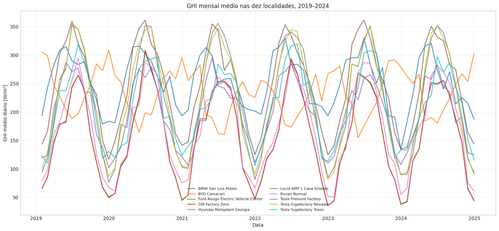

```python
# Calcula medias mensais apenas para visualizar tendencias de longo prazo.
series_mensais = []
for nome, dados in bases.items():
    mensal = (
        dados.set_index("data")[["ghi"]]
        .resample("ME")
        .mean()
        .reset_index()
    )
    mensal["localidade"] = nome
    series_mensais.append(mensal)

ghi_mensal = pd.concat(series_mensais, ignore_index=True)

fig, ax = plt.subplots(figsize=(15, 7))
for nome, grupo in ghi_mensal.groupby("localidade"):
    ax.plot(grupo["data"], grupo["ghi"], linewidth=1.5, alpha=0.9, label=nome)

ax.set_title("GHI mensal médio nas dez localidades, 2019–2024")
ax.set_xlabel("Data")
ax.set_ylabel("GHI médio diário [W/m²]")
ax.legend(ncol=2, fontsize=8)
ax.grid(True, alpha=0.3)
plt.tight_layout()
plt.show()
```

### 3.2 Séries históricas por localidade

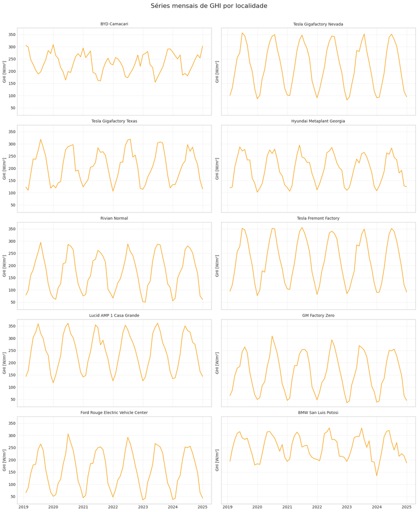

```python
# Separa as localidades em paineis com a mesma escala para comparacao justa.
fig, axes = plt.subplots(5, 2, figsize=(15, 18), sharex=True, sharey=True)

for ax, local in zip(axes.flat, LOCALIDADES_EV):
    grupo = ghi_mensal.loc[ghi_mensal["localidade"] == local["nome"]]
    ax.plot(grupo["data"], grupo["ghi"], color="#F9A825", linewidth=1.5)
    ax.set_title(local["nome"], fontsize=10)
    ax.set_ylabel("GHI [W/m²]")
    ax.grid(True, alpha=0.3)

fig.suptitle("Séries mensais de GHI por localidade", fontsize=16, y=1.01)
plt.tight_layout()
plt.show()
```

### 3.3 Médias anuais de GHI

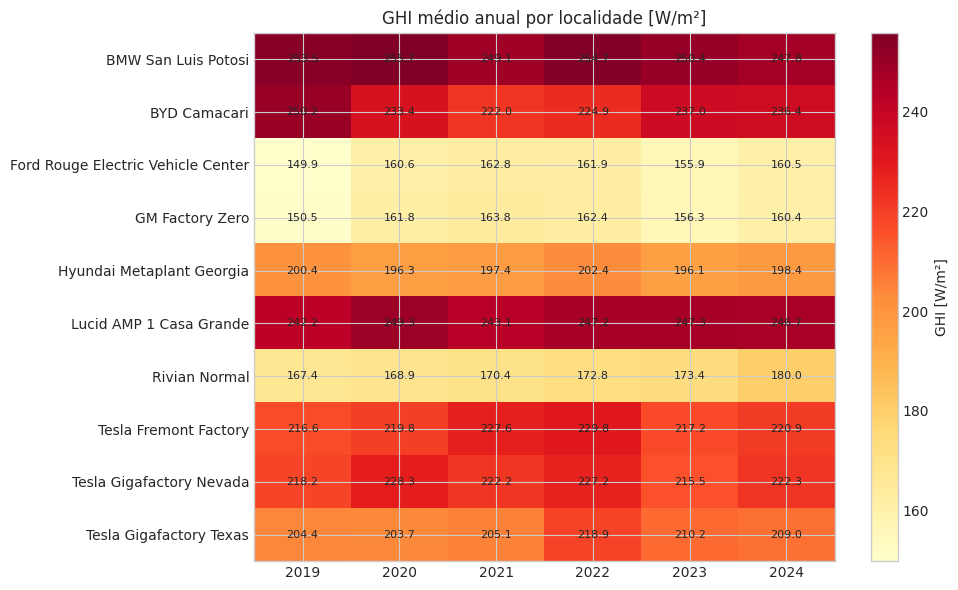

```python
# Resume cada ano e localidade em um mapa de calor de irradiancia media.
ghi_anual = (
    pd.concat(bases.values(), ignore_index=True)
    .groupby(["localidade", "ano"], as_index=False)["ghi"]
    .mean()
    .pivot(index="localidade", columns="ano", values="ghi")
)

fig, ax = plt.subplots(figsize=(10, 6))
imagem = ax.imshow(ghi_anual.values, aspect="auto", cmap="YlOrRd")
ax.set_xticks(range(len(ghi_anual.columns)), ghi_anual.columns)
ax.set_yticks(range(len(ghi_anual.index)), ghi_anual.index)
ax.set_title("GHI médio anual por localidade [W/m²]")

for i in range(ghi_anual.shape[0]):
    for j in range(ghi_anual.shape[1]):
        ax.text(j, i, f"{ghi_anual.iloc[i, j]:.1f}", ha="center", va="center", fontsize=8)

fig.colorbar(imagem, ax=ax, label="GHI [W/m²]")
plt.tight_layout()
plt.show()
```

A comparação evidencia diferenças sazonais e níveis médios distintos entre as localidades. As maiores médias do período foram observadas em San Luis Potosí, Casa Grande e Camaçari, enquanto os menores valores médios ocorreram nas localidades da região de Detroit e Dearborn.

## 4. Aplicação do pipeline de previsão

O processamento aplicado a cada localidade seguiu a metodologia descrita no notebook teórico do projeto. As mesmas etapas e os mesmos hiperparâmetros foram utilizados em todas as séries, permitindo a comparação dos resultados em condições equivalentes.

| Etapa | Procedimento adotado |
| --- | --- |
| Preparação da série | Ordenação cronológica, remoção de valores inválidos e agregação diária |
| Estatísticas horárias | Cálculo de média, sigma e COV (`sigma/média`) quando há dados horários disponíveis |
| Quantização | Conversão do GHI em 128 níveis discretos |
| Normalização | Escalonamento Min-Max para o intervalo entre 0 e 1 |
| Variáveis temporais | Defasagens de 1, 2, 3 e 7 dias |
| Médias móveis | Janelas de 3, 7 e 30 dias, calculadas somente com valores anteriores |
| Variável-alvo | GHI normalizado do dia seguinte |
| Divisão dos dados | 80% para treinamento e 20% para teste, em ordem cronológica |
| Modelos | XGBoost e MLPRegressor |
| Métricas | MAE, MSE, RMSE, R² e nRMSE, nas escalas normalizada e `W/m²` |

O XGBoost foi configurado com 300 estimadores, profundidade máxima igual a 3 e taxa de aprendizagem de 0,05. A rede neural MLP foi composta por duas camadas ocultas, com 64 e 32 neurônios, função de ativação ReLU e otimizador Adam.

Os parâmetros de quantização e normalização foram ajustados exclusivamente com o conjunto de treinamento, evitando a utilização de informações futuras durante a preparação dos dados. Após a previsão, o GHI foi desnormalizado para que as métricas também fossem calculadas na escala física aproximada em `W/m²`.

## 5. Resultados dos modelos

As métricas apresentadas nesta seção foram calculadas sobre a parcela final de 20% de cada série. Como a variável-alvo do treinamento foi quantizada e normalizada, os resultados mantêm a escala normalizada para rastreabilidade metodológica. Em paralelo, as previsões foram desnormalizadas para `W/m²`, permitindo interpretar MAE, RMSE e nRMSE na unidade física do GHI.

Também é carregada a tabela de estatísticas horárias. O COV horário (`sigma/média`) descreve a variabilidade dos dados horários originais e não deve ser interpretado como erro do modelo.

```python
# Carrega as metricas geradas pelo treinamento e prepara a exibicao arredondada.
metricas_file = RESULTADOS_DIR / "metricas_geral.csv"
resumo_file = RESULTADOS_DIR / "resumo_localidades.csv"
estatisticas_horarias_file = RESULTADOS_DIR / "estatisticas_horarias.csv"

if not metricas_file.exists() or not resumo_file.exists():
    raise FileNotFoundError("Os resultados dos modelos não foram localizados.")

if not estatisticas_horarias_file.exists():
    raise FileNotFoundError("As estatísticas horárias não foram localizadas.")

df_metricas = pd.read_csv(metricas_file)
df_resumo_modelos = pd.read_csv(resumo_file)
df_estatisticas_horarias = pd.read_csv(estatisticas_horarias_file)

colunas_metricas = [
    "Localidade", "Pais", "Modelo",
    "MAE_normalizado", "RMSE_normalizado",
    "MAE_wm2", "RMSE_wm2", "nRMSE_percentual_wm2", "R2_wm2",
]
metricas_exibicao = df_metricas[colunas_metricas].copy()
colunas_arredondar = [
    "MAE_normalizado", "RMSE_normalizado", "MAE_wm2",
    "RMSE_wm2", "nRMSE_percentual_wm2", "R2_wm2",
]
metricas_exibicao[colunas_arredondar] = metricas_exibicao[colunas_arredondar].round(4)
metricas_exibicao = metricas_exibicao.rename(
    columns={
        "MAE_wm2": "MAE (W/m²)",
        "RMSE_wm2": "RMSE (W/m²)",
        "nRMSE_percentual_wm2": "nRMSE (%)",
        "R2_wm2": "R² (W/m²)",
    }
)

display(metricas_exibicao)
```

|  | Localidade | Pais | Modelo | MAE_normalizado | RMSE_normalizado | MAE (W/m²) | RMSE (W/m²) | nRMSE (%) | R² (W/m²) |
| --- | --- | --- | --- | --- | --- | --- | --- | --- | --- |
| 0 | BYD Camacari | Brasil | XGBoost | 0.1239 | 0.1599 | 39.6444 | 51.1521 | 20.9578 | 0.3522 |
| 1 | BYD Camacari | Brasil | MLP | 0.1212 | 0.1553 | 38.7487 | 49.6677 | 20.3496 | 0.3892 |
| 2 | Tesla Gigafactory Nevada | EUA | XGBoost | 0.0737 | 0.1016 | 28.4705 | 39.2566 | 19.1262 | 0.8596 |
| 3 | Tesla Gigafactory Nevada | EUA | MLP | 0.0753 | 0.1048 | 29.0683 | 40.5051 | 19.7344 | 0.8505 |
| 4 | Tesla Gigafactory Texas | EUA | XGBoost | 0.1230 | 0.1585 | 43.6533 | 56.2683 | 28.7056 | 0.5537 |
| 5 | Tesla Gigafactory Texas | EUA | MLP | 0.1198 | 0.1553 | 42.5198 | 55.1284 | 28.1241 | 0.5716 |
| 6 | Hyundai Metaplant Georgia | EUA | XGBoost | 0.1341 | 0.1689 | 47.2536 | 59.5065 | 31.8833 | 0.4799 |
| 7 | Hyundai Metaplant Georgia | EUA | MLP | 0.1301 | 0.1624 | 45.8174 | 57.2385 | 30.6681 | 0.5188 |
| 8 | Rivian Normal | EUA | XGBoost | 0.1313 | 0.1681 | 48.1642 | 61.6709 | 37.4294 | 0.6133 |
| 9 | Rivian Normal | EUA | MLP | 0.1278 | 0.1622 | 46.8542 | 59.4983 | 36.1107 | 0.6401 |
| 10 | Tesla Fremont Factory | EUA | XGBoost | 0.0689 | 0.1021 | 25.0500 | 37.1089 | 18.1443 | 0.8701 |
| 11 | Tesla Fremont Factory | EUA | MLP | 0.0715 | 0.1026 | 26.0023 | 37.2911 | 18.2334 | 0.8688 |
| 12 | Lucid AMP 1 Casa Grande | EUA | XGBoost | 0.0638 | 0.0966 | 24.1587 | 36.5741 | 15.7436 | 0.8158 |
| 13 | Lucid AMP 1 Casa Grande | EUA | MLP | 0.0640 | 0.0966 | 24.1485 | 36.5412 | 15.7295 | 0.8161 |
| 14 | GM Factory Zero | EUA | XGBoost | 0.1264 | 0.1617 | 47.2362 | 60.4303 | 41.6795 | 0.6321 |
| 15 | GM Factory Zero | EUA | MLP | 0.1237 | 0.1608 | 46.2492 | 60.0880 | 41.4434 | 0.6362 |
| 16 | Ford Rouge Electric Vehicle Center | EUA | XGBoost | 0.1240 | 0.1577 | 46.0051 | 58.5057 | 40.3056 | 0.6515 |
| 17 | Ford Rouge Electric Vehicle Center | EUA | MLP | 0.1222 | 0.1585 | 45.3512 | 58.8207 | 40.5225 | 0.6477 |
| 18 | BMW San Luis Potosi | Mexico | XGBoost | 0.0988 | 0.1347 | 34.6063 | 47.1871 | 20.0800 | 0.5682 |
| 19 | BMW San Luis Potosi | Mexico | MLP | 0.0964 | 0.1314 | 33.7784 | 46.0053 | 19.5771 | 0.5895 |

### Análise da tabela de métricas

A tabela apresenta resultados coerentes com o comportamento esperado das métricas. Em todas as localidades, o `RMSE` é maior que o `MAE`, pois o RMSE penaliza mais fortemente erros grandes. Isso indica que não há inversão estranha nas métricas: quando existem erros pontuais maiores, eles aparecem com mais peso no RMSE.

Também há coerência entre erro e poder explicativo. Em geral, quando o `RMSE (W/m²)` diminui, o `R² (W/m²)` aumenta. Isso aparece claramente em localidades como Tesla Fremont Factory, Tesla Gigafactory Nevada e Lucid AMP 1 Casa Grande, que apresentam os menores erros e os maiores valores de R². Essas séries parecem mais previsíveis usando apenas o histórico do próprio GHI.

As localidades com maior erro relativo, como GM Factory Zero, Ford Rouge Electric Vehicle Center e Rivian Normal, têm `nRMSE (%)` mais alto. O nRMSE depende da média do GHI real da localidade; por isso, um erro absoluto parecido em `W/m²` pode representar uma porcentagem maior quando a média de irradiância é menor. Assim, o nRMSE é útil para comparar localidades com níveis médios de GHI diferentes.

A leitura principal para apresentação é:

```
Métricas normalizadas → mostram a escala usada pelo modelo.
Métricas em W/m²     → mostram o tamanho físico do erro.
nRMSE (%)            → mostra o erro em relação ao GHI médio da localidade.
R²                   → mostra quanto da variação da série foi explicada.
```

Portanto, os resultados não indicam erro de cálculo. Eles sugerem que o pipeline funciona melhor em localidades com comportamento solar diário mais regular e tem mais dificuldade onde há maior variabilidade não explicada apenas pelas defasagens e médias móveis. Como o modelo não usa nebulosidade, temperatura, umidade ou outras variáveis meteorológicas, essa variação residual é esperada.

### 5.1 Comparação das métricas

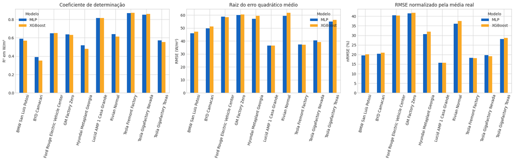

```python
# Compara R2, RMSE em W/m2 e nRMSE percentual dos dois modelos lado a lado.
fig, axes = plt.subplots(1, 3, figsize=(19, 6))

configuracoes = [
    ("R2_wm2", "Coeficiente de determinação", "R² em W/m²"),
    ("RMSE_wm2", "Raiz do erro quadrático médio", "RMSE (W/m²)"),
    ("nRMSE_percentual_wm2", "RMSE normalizado pela média real", "nRMSE (%)"),
]

for ax, (coluna, titulo, rotulo_y) in zip(axes, configuracoes):
    tabela = df_metricas.pivot(index="Localidade", columns="Modelo", values=coluna)
    tabela.plot(kind="bar", ax=ax, color=["#1565C0", "#F9A825"])
    ax.set_title(titulo)
    ax.set_xlabel("")
    ax.set_ylabel(rotulo_y)
    ax.tick_params(axis="x", rotation=75)
    ax.legend(title="Modelo")

plt.tight_layout()
plt.show()
```

### 5.2 Comparação entre valores observados e previstos

Os gráficos a seguir apresentam os valores reais e previstos no conjunto de teste na escala desnormalizada em `W/m²`. Essa representação permite observar o comportamento temporal dos dois modelos e também o tamanho físico das diferenças entre observado e previsto.

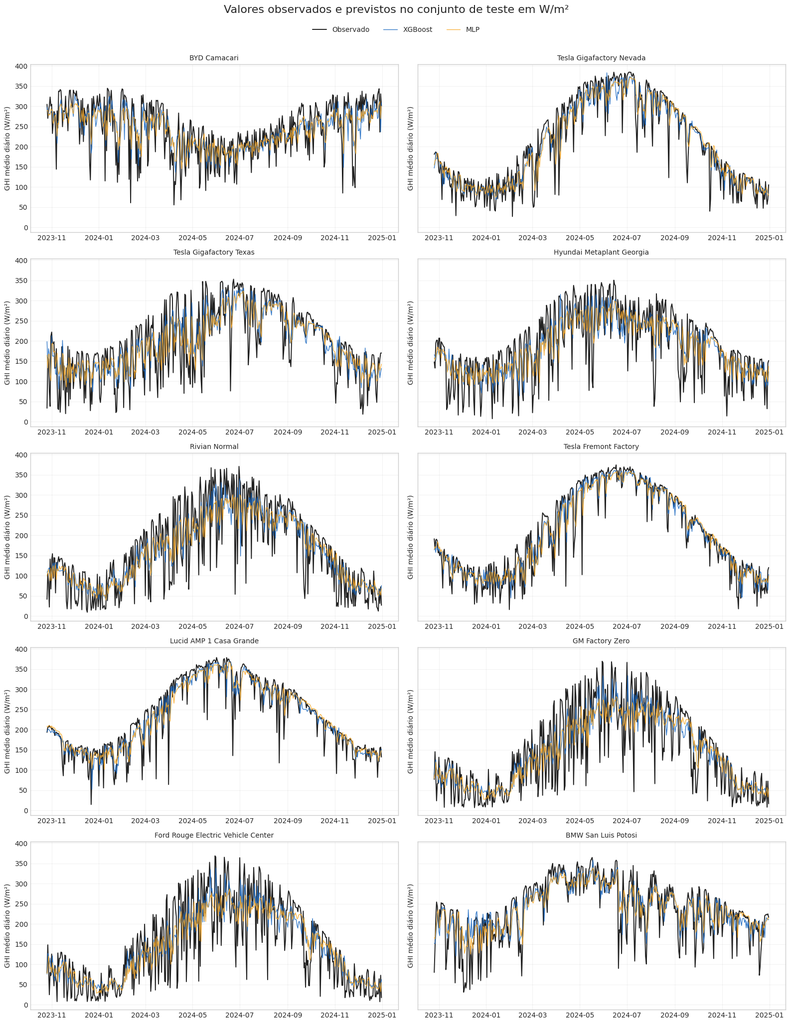

```python
# Mostra a sequencia real e as duas previsoes no periodo cronologico de teste em W/m2.
fig, axes = plt.subplots(5, 2, figsize=(16, 20), sharex=False, sharey=True)

for ax, local in zip(axes.flat, LOCALIDADES_EV):
    arquivo = PREVISOES_DIR / nome_arquivo(local["nome"]) / "previsoes_modelos.csv"
    previsoes = pd.read_csv(arquivo, parse_dates=["data"])

    ax.plot(previsoes["data"], previsoes["ghi_real_wm2"], color="#212121", linewidth=1.4, label="Observado")
    ax.plot(previsoes["data"], previsoes["ghi_previsto_xgboost_wm2"], color="#1565C0", linewidth=1.0, alpha=0.85, label="XGBoost")
    ax.plot(previsoes["data"], previsoes["ghi_previsto_mlp_wm2"], color="#F9A825", linewidth=1.0, alpha=0.85, label="MLP")
    ax.set_title(local["nome"], fontsize=10)
    ax.set_ylabel("GHI médio diário (W/m²)")
    ax.grid(True, alpha=0.25)

handles, labels = axes.flat[0].get_legend_handles_labels()
fig.legend(handles, labels, loc="upper center", ncol=3, bbox_to_anchor=(0.5, 1.01))
fig.suptitle("Valores observados e previstos no conjunto de teste em W/m²", fontsize=16, y=1.025)
plt.tight_layout()
plt.show()
```

### 5.3 Síntese por localidade

A tabela abaixo resume, para cada localidade, as métricas principais nas duas escalas. A definição do melhor modelo usa o maior `R2_wm2`, pois essa é a versão alinhada com a escala física apresentada nos gráficos.

```python
# Organiza uma linha por localidade para identificar o maior R2 em W/m2.
resumo_exibicao = df_resumo_modelos[
    [
        "Localidade",
        "XGBoost_RMSE_normalizado", "XGBoost_RMSE_wm2", "XGBoost_nRMSE_percentual_wm2", "XGBoost_R2_wm2",
        "MLP_RMSE_normalizado", "MLP_RMSE_wm2", "MLP_nRMSE_percentual_wm2", "MLP_R2_wm2",
        "Melhor_Modelo",
    ]
].copy()

colunas_numericas = [
    "XGBoost_RMSE_normalizado", "XGBoost_RMSE_wm2", "XGBoost_nRMSE_percentual_wm2", "XGBoost_R2_wm2",
    "MLP_RMSE_normalizado", "MLP_RMSE_wm2", "MLP_nRMSE_percentual_wm2", "MLP_R2_wm2",
]
resumo_exibicao[colunas_numericas] = resumo_exibicao[colunas_numericas].round(4)
resumo_exibicao = resumo_exibicao.rename(
    columns={
        "XGBoost_RMSE_normalizado": "XGBoost RMSE norm.",
        "XGBoost_RMSE_wm2": "XGBoost RMSE (W/m²)",
        "XGBoost_nRMSE_percentual_wm2": "XGBoost nRMSE (%)",
        "XGBoost_R2_wm2": "XGBoost R²",
        "MLP_RMSE_normalizado": "MLP RMSE norm.",
        "MLP_RMSE_wm2": "MLP RMSE (W/m²)",
        "MLP_nRMSE_percentual_wm2": "MLP nRMSE (%)",
        "MLP_R2_wm2": "MLP R²",
        "Melhor_Modelo": "Modelo com maior R²",
    }
)

display(resumo_exibicao)
```

|  | Localidade | XGBoost RMSE norm. | XGBoost RMSE (W/m²) | XGBoost nRMSE (%) | XGBoost R² | MLP RMSE norm. | MLP RMSE (W/m²) | MLP nRMSE (%) | MLP R² | Modelo com maior R² |
| --- | --- | --- | --- | --- | --- | --- | --- | --- | --- | --- |
| 0 | BYD Camacari | 0.1599 | 51.1521 | 20.9578 | 0.3522 | 0.1553 | 49.6677 | 20.3496 | 0.3892 | MLP |
| 1 | Tesla Gigafactory Nevada | 0.1016 | 39.2566 | 19.1262 | 0.8596 | 0.1048 | 40.5051 | 19.7344 | 0.8505 | XGBoost |
| 2 | Tesla Gigafactory Texas | 0.1585 | 56.2683 | 28.7056 | 0.5537 | 0.1553 | 55.1284 | 28.1241 | 0.5716 | MLP |
| 3 | Hyundai Metaplant Georgia | 0.1689 | 59.5065 | 31.8833 | 0.4799 | 0.1624 | 57.2385 | 30.6681 | 0.5188 | MLP |
| 4 | Rivian Normal | 0.1681 | 61.6709 | 37.4294 | 0.6133 | 0.1622 | 59.4983 | 36.1107 | 0.6401 | MLP |
| 5 | Tesla Fremont Factory | 0.1021 | 37.1089 | 18.1443 | 0.8701 | 0.1026 | 37.2911 | 18.2334 | 0.8688 | XGBoost |
| 6 | Lucid AMP 1 Casa Grande | 0.0966 | 36.5741 | 15.7436 | 0.8158 | 0.0966 | 36.5412 | 15.7295 | 0.8161 | MLP |
| 7 | GM Factory Zero | 0.1617 | 60.4303 | 41.6795 | 0.6321 | 0.1608 | 60.0880 | 41.4434 | 0.6362 | MLP |
| 8 | Ford Rouge Electric Vehicle Center | 0.1577 | 58.5057 | 40.3056 | 0.6515 | 0.1585 | 58.8207 | 40.5225 | 0.6477 | XGBoost |
| 9 | BMW San Luis Potosi | 0.1347 | 47.1871 | 20.0800 | 0.5682 | 0.1314 | 46.0053 | 19.5771 | 0.5895 | MLP |

### 5.4 Estatísticas horárias: sigma, média e COV

A tabela abaixo mostra a estatística solicitada sobre os dados horários: `COV = sigma / média`.

**Observação importante:** a API NLR/NSRDB fornece dados com intervalo de 60 minutos, mas os CSVs salvos neste projeto já estão agregados por média diária. A agregação é feita no pipeline com:

```
daily = df_year[["ghi"]].resample("D").mean()
```

Por isso os arquivos atuais têm uma linha por dia e metadados como:

```
intervalo_minutos = 60
agregacao = media_diaria
```

Depois que a série horária é reduzida para média diária, a variabilidade dentro do dia não pode ser reconstruída. Por esse motivo, o notebook indica `indisponivel_csv_diario` para o COV horário. Para preencher esse valor, seria necessário calcular `sigma/média` antes da agregação diária ou recoletar/recuperar os dados horários originais.

Com os CSVs atuais, seria possível calcular um COV diário, mas ele teria outro significado: variação entre dias, não variação horária da série original.

```python
# Exibe media, sigma e COV horario quando a informacao esta disponivel.
estatisticas_exibicao = df_estatisticas_horarias.copy()
colunas_cov = [
    "Localidade", "Pais", "ghi_horario_media", "ghi_horario_sigma",
    "ghi_horario_cov", "ghi_horario_cov_percentual",
    "ghi_horario_fonte_estatistica",
]
estatisticas_exibicao = estatisticas_exibicao[colunas_cov]
colunas_numericas_cov = [
    "ghi_horario_media", "ghi_horario_sigma",
    "ghi_horario_cov", "ghi_horario_cov_percentual",
]
estatisticas_exibicao[colunas_numericas_cov] = estatisticas_exibicao[colunas_numericas_cov].round(4)
estatisticas_exibicao = estatisticas_exibicao.rename(
    columns={
        "ghi_horario_media": "Média horária GHI",
        "ghi_horario_sigma": "Sigma horário GHI",
        "ghi_horario_cov": "COV",
        "ghi_horario_cov_percentual": "COV (%)",
        "ghi_horario_fonte_estatistica": "Fonte da estatística",
    }
)

display(estatisticas_exibicao)
```

|  | Localidade | Pais | Média horária GHI | Sigma horário GHI | COV | COV (%) | Fonte da estatística |
| --- | --- | --- | --- | --- | --- | --- | --- |
| 0 | BYD Camacari | Brasil | NaN | NaN | NaN | NaN | indisponivel_csv_diario |
| 1 | Tesla Gigafactory Nevada | EUA | NaN | NaN | NaN | NaN | indisponivel_csv_diario |
| 2 | Tesla Gigafactory Texas | EUA | NaN | NaN | NaN | NaN | indisponivel_csv_diario |
| 3 | Hyundai Metaplant Georgia | EUA | NaN | NaN | NaN | NaN | indisponivel_csv_diario |
| 4 | Rivian Normal | EUA | NaN | NaN | NaN | NaN | indisponivel_csv_diario |
| 5 | Tesla Fremont Factory | EUA | NaN | NaN | NaN | NaN | indisponivel_csv_diario |
| 6 | Lucid AMP 1 Casa Grande | EUA | NaN | NaN | NaN | NaN | indisponivel_csv_diario |
| 7 | GM Factory Zero | EUA | NaN | NaN | NaN | NaN | indisponivel_csv_diario |
| 8 | Ford Rouge Electric Vehicle Center | EUA | NaN | NaN | NaN | NaN | indisponivel_csv_diario |
| 9 | BMW San Luis Potosi | Mexico | NaN | NaN | NaN | NaN | indisponivel_csv_diario |

## 6. Discussão dos resultados

```python
# Extrai vencedores e gera automaticamente a discussao textual dos resultados.
melhor_xgb = df_resumo_modelos.loc[df_resumo_modelos["XGBoost_R2_wm2"].idxmax()]
melhor_mlp = df_resumo_modelos.loc[df_resumo_modelos["MLP_R2_wm2"].idxmax()]
vitorias_xgb = int((df_resumo_modelos["XGBoost_R2_wm2"] > df_resumo_modelos["MLP_R2_wm2"]).sum())
vitorias_mlp = int((df_resumo_modelos["MLP_R2_wm2"] > df_resumo_modelos["XGBoost_R2_wm2"]).sum())
rmse_medio_xgb = df_metricas.loc[df_metricas["Modelo"] == "XGBoost", "RMSE_wm2"].mean()
rmse_medio_mlp = df_metricas.loc[df_metricas["Modelo"] == "MLP", "RMSE_wm2"].mean()
nrmse_medio_xgb = df_metricas.loc[df_metricas["Modelo"] == "XGBoost", "nRMSE_percentual_wm2"].mean()
nrmse_medio_mlp = df_metricas.loc[df_metricas["Modelo"] == "MLP", "nRMSE_percentual_wm2"].mean()
fontes_cov = df_estatisticas_horarias["ghi_horario_fonte_estatistica"].value_counts().to_dict()

texto_discussao = f"""
Os resultados indicam que o desempenho dos modelos varia de acordo com a localidade e com a regularidade da série solar. O maior coeficiente de determinação do XGBoost foi obtido para **{melhor_xgb['Localidade']}**, com R² em W/m² igual a **{melhor_xgb['XGBoost_R2_wm2']:.4f}**. A MLP apresentou seu maior R² em **{melhor_mlp['Localidade']}**, com valor igual a **{melhor_mlp['MLP_R2_wm2']:.4f}**.

Considerando o maior R² em W/m² em cada localidade, o XGBoost apresentou melhor resultado em **{vitorias_xgb} localidades**, enquanto a MLP apresentou melhor resultado em **{vitorias_mlp} localidades**. Essa distribuição mostra que nenhum dos modelos foi superior em todos os casos.

A leitura em escala física facilita interpretar a magnitude dos erros: o RMSE médio do XGBoost foi de **{rmse_medio_xgb:.2f} W/m²**, com nRMSE médio de **{nrmse_medio_xgb:.2f}%**; para a MLP, o RMSE médio foi de **{rmse_medio_mlp:.2f} W/m²**, com nRMSE médio de **{nrmse_medio_mlp:.2f}%**.

Os melhores desempenhos foram observados em Fremont, Nevada e Casa Grande. Nessas localidades, os modelos reproduziram de maneira mais consistente a variação temporal do GHI. Em Camaçari, Texas, Georgia e San Luis Potosí, os menores valores de R² indicam maior dificuldade na representação das oscilações diárias por meio apenas das defasagens e médias móveis utilizadas.

A estatística horária COV = sigma/média foi incorporada ao pipeline. A API fornece dados com intervalo de 60 minutos, porém os CSVs disponíveis no projeto foram salvos depois da agregação por média diária. Nos resultados atuais, a coluna de fonte aparece como **{fontes_cov}**. Isso indica que a estrutura para registrar COV horário está pronta, mas o preenchimento numérico exige calcular a estatística antes da agregação diária ou recoletar/recuperar a série horária original.

De forma geral, os resultados demonstram que o pipeline é aplicável às diferentes séries, mas também evidenciam que a capacidade preditiva depende das características climáticas de cada região. A inclusão futura de variáveis meteorológicas adicionais, como nebulosidade, temperatura, umidade e velocidade do vento, poderá ampliar a capacidade explicativa dos modelos.
"""

display(Markdown(texto_discussao))
```

Os resultados indicam que o desempenho dos modelos varia de acordo com a localidade e com a regularidade da série solar. O maior coeficiente de determinação do XGBoost foi obtido para **Tesla Fremont Factory**, com R² em W/m² igual a **0.8701**. A MLP apresentou seu maior R² em **Tesla Fremont Factory**, com valor igual a **0.8688**.

Considerando o maior R² em W/m² em cada localidade, o XGBoost apresentou melhor resultado em **3 localidades**, enquanto a MLP apresentou melhor resultado em **7 localidades**. Essa distribuição mostra que nenhum dos modelos foi superior em todos os casos.

A leitura em escala física facilita interpretar a magnitude dos erros: o RMSE médio do XGBoost foi de **50.77 W/m²**, com nRMSE médio de **27.41%**; para a MLP, o RMSE médio foi de **50.08 W/m²**, com nRMSE médio de **27.05%**.

Os melhores desempenhos foram observados em Fremont, Nevada e Casa Grande. Nessas localidades, os modelos reproduziram de maneira mais consistente a variação temporal do GHI. Em Camaçari, Texas, Georgia e San Luis Potosí, os menores valores de R² indicam maior dificuldade na representação das oscilações diárias por meio apenas das defasagens e médias móveis utilizadas.

A estatística horária COV = sigma/média foi incorporada ao pipeline. A API fornece dados com intervalo de 60 minutos, porém os CSVs disponíveis no projeto foram salvos depois da agregação por média diária. Nos resultados atuais, a coluna de fonte aparece como **{'indisponivel_csv_diario': 10}**. Isso indica que a estrutura para registrar COV horário está pronta, mas o preenchimento numérico exige calcular a estatística antes da agregação diária ou recoletar/recuperar a série horária original.

De forma geral, os resultados demonstram que o pipeline é aplicável às diferentes séries, mas também evidenciam que a capacidade preditiva depende das características climáticas de cada região. A inclusão futura de variáveis meteorológicas adicionais, como nebulosidade, temperatura, umidade e velocidade do vento, poderá ampliar a capacidade explicativa dos modelos.

## 7. Conclusão

O estudo reuniu séries diárias de GHI para dez localidades associadas a fábricas de veículos elétricos e aplicou, de forma padronizada, um pipeline de previsão baseado em XGBoost e MLP.

A base utilizada apresentou cobertura diária completa entre 2019 e 2024, com origem e coordenadas documentadas. A análise exploratória permitiu identificar diferenças sazonais e níveis médios de irradiância distintos entre as regiões estudadas.

Na etapa de modelagem, os dois algoritmos apresentaram resultados competitivos, sem predominância absoluta de um único método. A avaliação foi ampliada para incluir métricas normalizadas, métricas desnormalizadas em `W/m²`, nRMSE e tabelas de previsão com valores reais e previstos lado a lado. Essa apresentação torna os resultados mais adequados para discussão física, pois mostra o erro na unidade original do GHI.

O pipeline também passou a prever o registro de média, sigma e COV dos dados horários. Como os arquivos locais atuais já foram salvos após a agregação diária, o COV horário permanece marcado como indisponível até que a estatística seja calculada durante a coleta horária ou até uma nova recuperação da série horária original. Os resultados confirmam a viabilidade do procedimento adotado e estabelecem uma referência para etapas posteriores de aprimoramento do modelo e inclusão de novas variáveis explicativas.

## Referências e fontes de dados

- National Laboratory of the Rockies. **NSRDB GOES Aggregated PSM v4**. Disponível em: https://developer.nlr.gov/docs/solar/nsrdb/nsrdb-GOES-aggregated-v4-0-0-download/.
- OpenStreetMap Contributors. **OpenStreetMap**. Disponível em: https://www.openstreetmap.org/.
- Nominatim. **Open-source geocoding with OpenStreetMap data**. Disponível em: https://nominatim.org/.
- As páginas institucionais utilizadas para identificação das fábricas encontram-se relacionadas na Tabela da Seção 2.2.
- XGBoost Documentation. Disponível em: https://xgboost.readthedocs.io/.
- Scikit-learn. **MLPRegressor**. Disponível em: https://scikit-learn.org/stable/modules/generated/sklearn.neural_network.MLPRegressor.html.